# Customer Segmentation

##### Created on 10-08-2022

### Background: The transaction data for channel partners(customer) of a large FMCG company is available. The data available is for two years -by month of the year and brand. The marketing team wants to create segments of customers based on transaction pattern so that marketing strategies can be developed for each segment.

## Objectives:

1. To create segments of similar customers which can be used for marketing strategies

### Data Description:

| Column Name | Description |
| --- | --- |
| Customer ID | Customer ID for each customer |
| Month | Month of transaction |
| Brand | Brand purchased |
| Year | Year of transaction |
| Sales | Total sales in INR |

### Libraries used:

| Library | Application |
| --- | --- |
| pandas | To handle data frames in python |
| matplotlib/seaborn | Plotting graphs |
| numpy | Adding support for large, multi-dimensional arrays |
| sklearn.preprocessing | Used for transforming/standardizing data |
| sklearn.cluster | To use KMeans algorithm |
| sklearn.decomposition | To run Principal Component Analysis (PCA) |
| warnings | To disable warnings |

```python
import pandas as pd
import matplotlib.pyplot as plt
import seaborn as sns
import numpy as np
import sklearn.preprocessing

from sklearn.cluster import KMeans
from sklearn.decomposition import PCA

import warnings
warnings.filterwarnings("ignore", category=FutureWarning)
```

### Import

```python
data = pd.read_csv("D:/projects/HR/cluster/Transaction data for Segmentation.csv")
data
```

|  | CustomerID | Month | Brand | Year | Sales |
| --- | --- | --- | --- | --- | --- |
| 0 | 10000 | 5 | B4 | 2021 | 21830.69 |
| 1 | 10000 | 10 | B5 | 2021 | 7221.56 |
| 2 | 10000 | 8 | B1 | 2021 | 29684.44 |
| 3 | 10000 | 10 | B3 | 2021 | 1573.06 |
| 4 | 10000 | 1 | B2 | 2020 | 4016.70 |
| ... | ... | ... | ... | ... | ... |
| 499995 | 99998 | 12 | B3 | 2020 | 7231.77 |
| 499996 | 99998 | 3 | B3 | 2020 | 27098.23 |
| 499997 | 99998 | 12 | B1 | 2020 | 65831.61 |
| 499998 | 99999 | 6 | B2 | 2021 | 3627.16 |
| 499999 | 99999 | 1 | B4 | 2021 | 27147.40 |

500000 rows × 5 columns

### Table of derived variables used for customer segmentation:

| Column Name | Description |
| --- | --- |
| Sales_21 | Total sales for year 2021 |
| Sales_B1_21 | Total sales for year 2021 for brand B1 (coffee) |
| Buying_Freq21 | Number of unique months of purchase in the year 2021 |
| Buying_FreqB121 | Number of unique months of purchase of brand B1 in the year 2021 |
| BrandEng_21 | Number of unique brands of purchase in 2021 |
| B121_Contribution | Contribution of Brand b1 to total in 2021 = sales in b1 /total sales for each customer*100 |

```python
#Creating a subset for year 2021
df = data.query('Year == 2021')
df.head()
```

|  | CustomerID | Month | Brand | Year | Sales |
| --- | --- | --- | --- | --- | --- |
| 0 | 10000 | 5 | B4 | 2021 | 21830.69 |
| 1 | 10000 | 10 | B5 | 2021 | 7221.56 |
| 2 | 10000 | 8 | B1 | 2021 | 29684.44 |
| 3 | 10000 | 10 | B3 | 2021 | 1573.06 |
| 6 | 10001 | 3 | B2 | 2021 | 39299.76 |

```python
df['Year'].unique()
```

```
array([2021], dtype=int64)
```

### Derive the following variables:

#### 1. Sales_21

```python
df1 = df.groupby(['CustomerID'])['Sales'].sum().reset_index()
df1.rename(columns = {'Sales':'Sales_21'},inplace = True)
df1
```

|  | CustomerID | Sales_21 |
| --- | --- | --- |
| 0 | 10000 | 60309.75 |
| 1 | 10001 | 68859.11 |
| 2 | 10004 | 69956.96 |
| 3 | 10005 | 9233.57 |
| 4 | 10006 | 93586.85 |
| ... | ... | ... |
| 84389 | 99995 | 152032.49 |
| 84390 | 99996 | 106558.42 |
| 84391 | 99997 | 98744.25 |
| 84392 | 99998 | 17968.88 |
| 84393 | 99999 | 30774.56 |

84394 rows × 2 columns

#### 2. Sales_B1_21

```python
df2 = df.query('Brand == "B1"').groupby(['CustomerID'])['Sales'].sum().reset_index()
df2.rename(columns = {'Sales':'Sales_B1_21'},inplace = True)
df2
```

|  | CustomerID | Sales_B1_21 |
| --- | --- | --- |
| 0 | 10000 | 29684.44 |
| 1 | 10001 | 26593.40 |
| 2 | 10004 | 6824.23 |
| 3 | 10006 | 7789.73 |
| 4 | 10010 | 11057.63 |
| ... | ... | ... |
| 37695 | 99991 | 51928.15 |
| 37696 | 99994 | 37534.86 |
| 37697 | 99995 | 42573.47 |
| 37698 | 99996 | 28506.06 |
| 37699 | 99998 | 8971.28 |

37700 rows × 2 columns

#### 3. Buying_Freq21

```python
df3= df.groupby('CustomerID')['Month'].nunique().reset_index()
df3.rename(columns = {'Month':'Buying_Freq21'},inplace = True)
df3
```

|  | CustomerID | Buying_Freq21 |
| --- | --- | --- |
| 0 | 10000 | 3 |
| 1 | 10001 | 4 |
| 2 | 10004 | 3 |
| 3 | 10005 | 2 |
| 4 | 10006 | 5 |
| ... | ... | ... |
| 84389 | 99995 | 7 |
| 84390 | 99996 | 4 |
| 84391 | 99997 | 4 |
| 84392 | 99998 | 2 |
| 84393 | 99999 | 2 |

84394 rows × 2 columns

#### 4. Buying_FreqB121

```python
df4 = df.query('Brand == "B1"').groupby('CustomerID')['Month'].nunique().reset_index()
df4.rename(columns = {'Month':'Buying_FreqB121'},inplace = True)
df4
```

|  | CustomerID | Buying_FreqB121 |
| --- | --- | --- |
| 0 | 10000 | 1 |
| 1 | 10001 | 2 |
| 2 | 10004 | 1 |
| 3 | 10006 | 1 |
| 4 | 10010 | 1 |
| ... | ... | ... |
| 37695 | 99991 | 1 |
| 37696 | 99994 | 1 |
| 37697 | 99995 | 2 |
| 37698 | 99996 | 2 |
| 37699 | 99998 | 1 |

37700 rows × 2 columns

#### 5. BrandEng_21

```python
df5 = df.groupby('CustomerID')['Brand'].nunique().reset_index()
df5.rename(columns = {'Brand':'BrandEng_21'},inplace = True)
df5
```

|  | CustomerID | BrandEng_21 |
| --- | --- | --- |
| 0 | 10000 | 4 |
| 1 | 10001 | 2 |
| 2 | 10004 | 3 |
| 3 | 10005 | 2 |
| 4 | 10006 | 4 |
| ... | ... | ... |
| 84389 | 99995 | 4 |
| 84390 | 99996 | 3 |
| 84391 | 99997 | 2 |
| 84392 | 99998 | 2 |
| 84393 | 99999 | 2 |

84394 rows × 2 columns

#### 6. B1_21Contribution

```python
#Merging all the above columns
finaldf = pd.merge(pd.merge(pd.merge(pd.merge(df1,df2,on = ['CustomerID'],how = 'outer'),df3,on = ['CustomerID'],how = 'outer'),df4,on = ['CustomerID'],how = 'outer'),df5,on = ['CustomerID'],how = 'outer')
finaldf
```

|  | CustomerID | Sales_21 | Sales_B1_21 | Buying_Freq21 | Buying_FreqB121 | BrandEng_21 |
| --- | --- | --- | --- | --- | --- | --- |
| 0 | 10000 | 60309.75 | 29684.44 | 3 | 1.0 | 4 |
| 1 | 10001 | 68859.11 | 26593.40 | 4 | 2.0 | 2 |
| 2 | 10004 | 69956.96 | 6824.23 | 3 | 1.0 | 3 |
| 3 | 10005 | 9233.57 | NaN | 2 | NaN | 2 |
| 4 | 10006 | 93586.85 | 7789.73 | 5 | 1.0 | 4 |
| ... | ... | ... | ... | ... | ... | ... |
| 84389 | 99995 | 152032.49 | 42573.47 | 7 | 2.0 | 4 |
| 84390 | 99996 | 106558.42 | 28506.06 | 4 | 2.0 | 3 |
| 84391 | 99997 | 98744.25 | NaN | 4 | NaN | 2 |
| 84392 | 99998 | 17968.88 | 8971.28 | 2 | 1.0 | 2 |
| 84393 | 99999 | 30774.56 | NaN | 2 | NaN | 2 |

84394 rows × 6 columns

```python
finaldf['B121_Contribution'] = (finaldf['Sales_B1_21']/finaldf['Sales_21'])*100
finaldf
```

|  | CustomerID | Sales_21 | Sales_B1_21 | Buying_Freq21 | Buying_FreqB121 | BrandEng_21 | B121_Contribution |
| --- | --- | --- | --- | --- | --- | --- | --- |
| 0 | 10000 | 60309.75 | 29684.44 | 3 | 1.0 | 4 | 49.219969 |
| 1 | 10001 | 68859.11 | 26593.40 | 4 | 2.0 | 2 | 38.620017 |
| 2 | 10004 | 69956.96 | 6824.23 | 3 | 1.0 | 3 | 9.754898 |
| 3 | 10005 | 9233.57 | NaN | 2 | NaN | 2 | NaN |
| 4 | 10006 | 93586.85 | 7789.73 | 5 | 1.0 | 4 | 8.323530 |
| ... | ... | ... | ... | ... | ... | ... | ... |
| 84389 | 99995 | 152032.49 | 42573.47 | 7 | 2.0 | 4 | 28.002876 |
| 84390 | 99996 | 106558.42 | 28506.06 | 4 | 2.0 | 3 | 26.751579 |
| 84391 | 99997 | 98744.25 | NaN | 4 | NaN | 2 | NaN |
| 84392 | 99998 | 17968.88 | 8971.28 | 2 | 1.0 | 2 | 49.926762 |
| 84393 | 99999 | 30774.56 | NaN | 2 | NaN | 2 | NaN |

84394 rows × 7 columns

### Replacing NaN values with 0 since NA values are generated if there is no transaction

```python
finaldf = finaldf.fillna(0)
finaldf
```

|  | CustomerID | Sales_21 | Sales_B1_21 | Buying_Freq21 | Buying_FreqB121 | BrandEng_21 | B121_Contribution |
| --- | --- | --- | --- | --- | --- | --- | --- |
| 0 | 10000 | 60309.75 | 29684.44 | 3 | 1.0 | 4 | 49.219969 |
| 1 | 10001 | 68859.11 | 26593.40 | 4 | 2.0 | 2 | 38.620017 |
| 2 | 10004 | 69956.96 | 6824.23 | 3 | 1.0 | 3 | 9.754898 |
| 3 | 10005 | 9233.57 | 0.00 | 2 | 0.0 | 2 | 0.000000 |
| 4 | 10006 | 93586.85 | 7789.73 | 5 | 1.0 | 4 | 8.323530 |
| ... | ... | ... | ... | ... | ... | ... | ... |
| 84389 | 99995 | 152032.49 | 42573.47 | 7 | 2.0 | 4 | 28.002876 |
| 84390 | 99996 | 106558.42 | 28506.06 | 4 | 2.0 | 3 | 26.751579 |
| 84391 | 99997 | 98744.25 | 0.00 | 4 | 0.0 | 2 | 0.000000 |
| 84392 | 99998 | 17968.88 | 8971.28 | 2 | 1.0 | 2 | 49.926762 |
| 84393 | 99999 | 30774.56 | 0.00 | 2 | 0.0 | 2 | 0.000000 |

84394 rows × 7 columns

#### Dropping CustomerID (Not required for clustering )

```python
finaldf.drop(['CustomerID'],axis = 1,inplace = True)
finaldf
```

|  | Sales_21 | Sales_B1_21 | Buying_Freq21 | Buying_FreqB121 | BrandEng_21 | B121_Contribution |
| --- | --- | --- | --- | --- | --- | --- |
| 0 | 60309.75 | 29684.44 | 3 | 1.0 | 4 | 49.219969 |
| 1 | 68859.11 | 26593.40 | 4 | 2.0 | 2 | 38.620017 |
| 2 | 69956.96 | 6824.23 | 3 | 1.0 | 3 | 9.754898 |
| 3 | 9233.57 | 0.00 | 2 | 0.0 | 2 | 0.000000 |
| 4 | 93586.85 | 7789.73 | 5 | 1.0 | 4 | 8.323530 |
| ... | ... | ... | ... | ... | ... | ... |
| 84389 | 152032.49 | 42573.47 | 7 | 2.0 | 4 | 28.002876 |
| 84390 | 106558.42 | 28506.06 | 4 | 2.0 | 3 | 26.751579 |
| 84391 | 98744.25 | 0.00 | 4 | 0.0 | 2 | 0.000000 |
| 84392 | 17968.88 | 8971.28 | 2 | 1.0 | 2 | 49.926762 |
| 84393 | 30774.56 | 0.00 | 2 | 0.0 | 2 | 0.000000 |

84394 rows × 6 columns

### Standardize the data using scale()

```python
df_scaled = sklearn.preprocessing.scale(finaldf)
df_scaled
```

```
array([[ 0.03426138,  0.95336768,  0.28244253,  0.60188426,  1.71624272,
         0.99641554],
       [ 0.24221196,  0.79131458,  1.05978584,  1.98742804, -0.28069086,
         0.64072867],
       [ 0.26891554, -0.24511825,  0.28244253,  0.60188426,  0.71777593,
        -0.32785536],
       ...,
       [ 0.96912392, -0.60289027,  1.05978584, -0.78365952, -0.28069086,
        -0.65518602],
       [-0.99561784, -0.13255545, -0.49490078,  0.60188426, -0.28069086,
         1.02013237],
       [-0.68413856, -0.60289027, -0.49490078, -0.78365952, -0.28069086,
        -0.65518602]])
```

```python
len(df_scaled)
```

```
84394
```

### Create plot for elbow method to decide optimum number of clusters

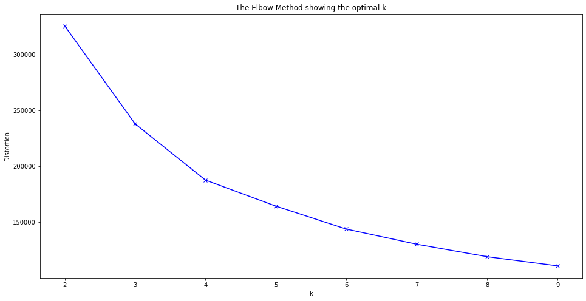

```python
distortions = []
K = range(2,10)
for k in K:
    kmeanModel = KMeans(n_clusters=k)
    kmeanModel.fit(df_scaled)
    distortions.append(kmeanModel.inertia_)

plt.figure(figsize=(16,8))
plt.plot(K, distortions, 'bx-')
plt.xlabel('k')
plt.ylabel('Distortion')
plt.title('The Elbow Method showing the optimal k')
plt.show()
```

### Comment : Using elbow method, K=4 clusters are finalised

### Running KMeans model

```python
CL = KMeans(n_clusters=4,random_state=3425)
CL.fit(df_scaled)
# Compute centroids
centroids = CL.cluster_centers_
centroids
```

```
array([[ 0.51844454, -0.38701606,  0.72500442, -0.18770332,  0.77663144,
        -0.44531167],
       [-0.48464843,  0.7485061 , -0.48713185,  0.880739  , -0.42769861,
         1.74367491],
       [ 1.31722361,  1.75107974,  1.1676669 ,  1.47221507,  1.05125506,
         0.76448545],
       [-0.62434629, -0.5887597 , -0.72923918, -0.70054647, -0.75393201,
        -0.62581411]])
```

### Add cluster membership to the data

```python
segment = pd.DataFrame(CL.labels_)
custsales = finaldf.assign(segment = segment)
custsales['segment'] = custsales['segment']+1
custsales.head()
```

|  | Sales_21 | Sales_B1_21 | Buying_Freq21 | Buying_FreqB121 | BrandEng_21 | B121_Contribution | segment |
| --- | --- | --- | --- | --- | --- | --- | --- |
| 0 | 60309.75 | 29684.44 | 3 | 1.0 | 4 | 49.219969 | 3 |
| 1 | 68859.11 | 26593.40 | 4 | 2.0 | 2 | 38.620017 | 3 |
| 2 | 69956.96 | 6824.23 | 3 | 1.0 | 3 | 9.754898 | 1 |
| 3 | 9233.57 | 0.00 | 2 | 0.0 | 2 | 0.000000 | 4 |
| 4 | 93586.85 | 7789.73 | 5 | 1.0 | 4 | 8.323530 | 1 |

```python
len(custsales)
```

```
84394
```

### Computing Cluster size(No. of customers in each cluster)

```python
custsales.groupby('segment')['segment'].count()
```

```
segment
1    25495
2    13804
3    11123
4    33972
Name: segment, dtype: int64
```

### Visualising cluster solution using two principal components of variables used in the clustering algorithm

```python
pca = PCA().fit(df_scaled)
val = PCA().fit_transform(df_scaled)
pca_df = pd.DataFrame(val)
pca_df = pca_df[[0,1]]
pca_df.columns = ['Dim1','Dim2']
finaldata = pd.concat([custsales,pca_df],axis = 1)
finaldata
```

|  | Sales_21 | Sales_B1_21 | Buying_Freq21 | Buying_FreqB121 | BrandEng_21 | B121_Contribution | segment | Dim1 | Dim2 |
| --- | --- | --- | --- | --- | --- | --- | --- | --- | --- |
| 0 | 60309.75 | 29684.44 | 3 | 1.0 | 4 | 49.219969 | 3 | 1.818920 | -0.276034 |
| 1 | 68859.11 | 26593.40 | 4 | 2.0 | 2 | 38.620017 | 3 | 1.881767 | -0.886654 |
| 2 | 69956.96 | 6824.23 | 3 | 1.0 | 3 | 9.754898 | 1 | 0.581660 | 0.574651 |
| 3 | 9233.57 | 0.00 | 2 | 0.0 | 2 | 0.000000 | 4 | -1.633986 | 0.104992 |
| 4 | 93586.85 | 7789.73 | 5 | 1.0 | 4 | 8.323530 | 1 | 1.878717 | 1.815772 |
| ... | ... | ... | ... | ... | ... | ... | ... | ... | ... |
| 84389 | 152032.49 | 42573.47 | 7 | 2.0 | 4 | 28.002876 | 3 | 4.756426 | 1.479856 |
| 84390 | 106558.42 | 28506.06 | 4 | 2.0 | 3 | 26.751579 | 3 | 2.580804 | 0.028901 |
| 84391 | 98744.25 | 0.00 | 4 | 0.0 | 2 | 0.000000 | 1 | -0.094044 | 1.489252 |
| 84392 | 17968.88 | 8971.28 | 2 | 1.0 | 2 | 49.926762 | 2 | -0.207534 | -1.393337 |
| 84393 | 30774.56 | 0.00 | 2 | 0.0 | 2 | 0.000000 | 4 | -1.421024 | 0.286991 |

84394 rows × 9 columns

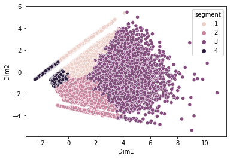

```python
sns.scatterplot(finaldata['Dim1'],finaldata['Dim2'] ,hue = finaldata['segment'])
```

```python
pca = PCA(n_components=2)
pca.fit(df_scaled)
print(pca.explained_variance_ratio_)
```

```
[0.52467703 0.30618769]
```

### Comment : First principal component explains 52% of the variation whereas, second component explains 30.6%

### Calculate mean of each variable clusterwise

```python
seg_analysis = custsales.groupby('segment')['Sales_21', 'Sales_B1_21', 'Buying_Freq21', 'Buying_FreqB121',
       'BrandEng_21', 'B121_Contribution'].mean().reset_index().round(2)
seg_analysis
```

|  | segment | Sales_21 | Sales_B1_21 | Buying_Freq21 | Buying_FreqB121 | BrandEng_21 | B121_Contribution |
| --- | --- | --- | --- | --- | --- | --- | --- |
| 0 | 1 | 80252.08 | 4137.85 | 3.57 | 0.43 | 3.06 | 6.27 |
| 1 | 2 | 38953.97 | 25758.06 | 2.01 | 1.20 | 1.85 | 71.48 |
| 2 | 3 | 113083.08 | 44978.39 | 4.14 | 1.63 | 3.33 | 42.38 |
| 3 | 4 | 33243.14 | 269.34 | 1.70 | 0.06 | 1.53 | 0.87 |

```python
col_list = ['Sales_21','Buying_Freq21', 'BrandEng_21', 'Sales_B1_21','Buying_FreqB121',
       'B121_Contribution']
```

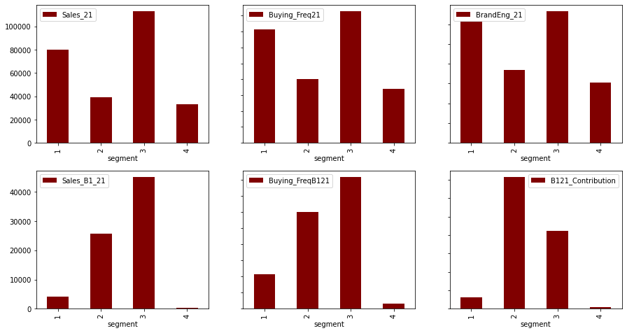

```python
# Now create a figure
fig, axes = plt.subplots(nrows=2, ncols=3, figsize=(15,8))
axe = axes.ravel()

# Now plot each zone on a particular axis
for i, cols in enumerate(col_list):
    seg_analysis.plot.bar('segment',cols,color = 'maroon',ax=axe[i],sharey=True )
```

## Comment: Cluster 3 appears to be a cluster of “Platinum” customers whereas customers in cluster 4 is a group of under performers. Customers in cluster 1 are next to “Platinum” group but non-buyers of brand B1 relatively. Cluster 2 customers are mainly buying brand B1